# Multivariate Fish Analysis

Nick Toimieri

# 1 Import and manipulate data

- Combined 2015 and 2016-2019 data
- Corrected some spp codes
- Make a ‘group’ variable for lumping taxa/species
- No depth data for the 2015 data.
  - I took the average of the quadrats.
  - I assigned transects with an average depth of >20 ft to the 10-m group.

NOTE: Transects with visibility < 2.2 m were deleted from the analysis.

DATA TRANSFORM: none

NOTES

- Some rockfish were recorded in the ‘adult’ category (eg SECA instead of SECAy) but were small.
- Set minimum size for rockfishes to 6 cm. Fish <= to 6 cm were classified as YOY.
- Maintained their original desigation in SPECIES column. New designation in the ‘group’ column.

Species included and the higher grouping used in the analyses are:

```
##    Spp_Code Spp_Group            Common_Name
## 1  BAITBALL      BAIT  bait-sardines-anchovy
## 4    SEBYTy    SEBYTy   yellowtail-black yoy
## 5      SEME      SEME         black rockfish
## 8      SEMY      SEMY          blue rockfish
## 12     SCMA      SCMA                cabezon
## 14    SEPIy     SEPIy    canary rockfish YOY
## 15     SENE      SENE         china rockfish
## 17     SECA      SECA        copper rockfish
## 20     HEXA      HEXA        Hexagrammos spp
## 23     CLUP      BAIT                Herring
## 25     HEDE      HEXA         Kelp Greenling
## 26     BRFR      EMBI         Kelp Surfperch
## 29     OPEL      OPEL                Lingcod
## 34     ENMO      BAIT       Northern Anchovy
## 38     SASA      BAIT        pacific sardine
## 39     OXPI      HEXA      Painted Greenling
## 41     RHVA      EMBI             Pile perch
## 45     HEHE      HEXA         Red Irish Lord
## 47     HELA      HEXA         Rock Greenling
## 49     RYOY      RYOY           rockfish_yoy
## 55     CYAG      EMBI       Shiner Surfperch
## 60     EMLA      EMBI      Striped Surfperch
## 61     EMBI      EMBI            Surfperches
## 63     AUFL      AUFL              Tubesnout
## 66     HEST      HEXA Whitespotted greenling
## 68     SEFL      SEFL    Yellowtail rockfish
```

## 1.1 Year x Site x Depth

No text here.

## 1.2 Year x Site

No text here.

# 2 nMDS: Year by Site by Depth (zone)

The stress for the nMDS including data averaged by year, site and depth was pretty good at stress = 0.18.

```
##
## Call:
## metaMDS(comm = fish_YSD, distance = "bray", k = 2, autotransform = TRUE)
##
## global Multidimensional Scaling using monoMDS
##
## Data:     wisconsin(sqrt(fish_YSD))
## Distance: bray
##
## Dimensions: 2
## Stress:     0.184293
## Stress type 1, weak ties
## Two convergent solutions found after 20 tries
## Scaling: centring, PC rotation, halfchange scaling
## Species: expanded scores based on 'wisconsin(sqrt(fish_YSD))'
```

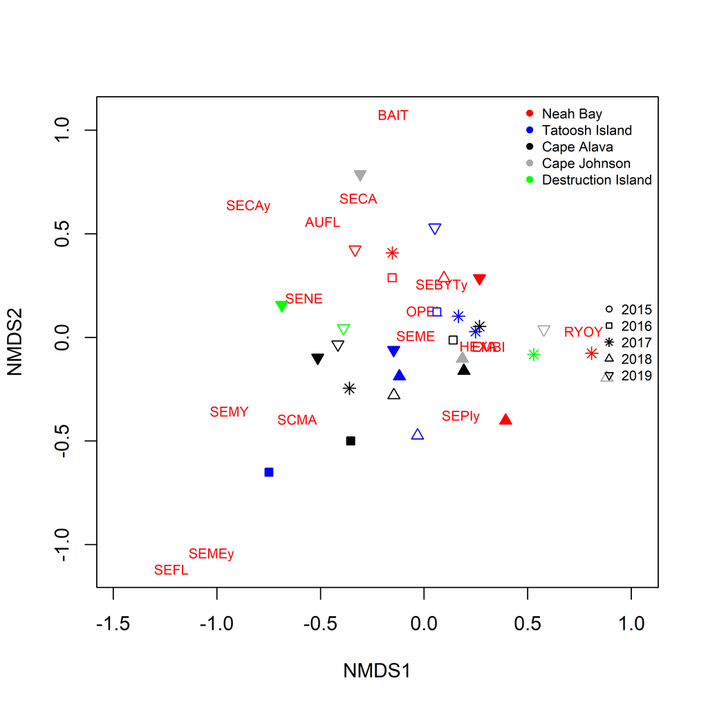

nMDS ordination plot of mean fish abudnace by site x year x depth zone. Closed circles = 5 m, open circles = 10 m.

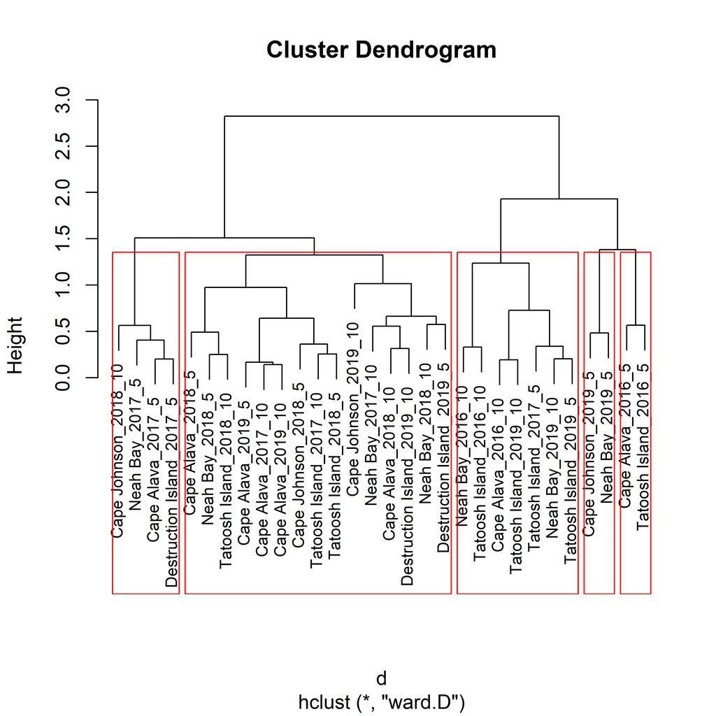

# Year by Site nMDS

```
##
## Call:
## metaMDS(comm = fish_YS, distance = "bray", k = 2, autotransform = TRUE)
##
## global Multidimensional Scaling using monoMDS
##
## Data:     wisconsin(sqrt(fish_YS))
## Distance: bray
##
## Dimensions: 2
## Stress:     0.1315752
## Stress type 1, weak ties
## Two convergent solutions found after 20 tries
## Scaling: centring, PC rotation, halfchange scaling
## Species: expanded scores based on 'wisconsin(sqrt(fish_YS))'
```

The year x site ordination is pretty good. Low stress and some clear separation among sites.

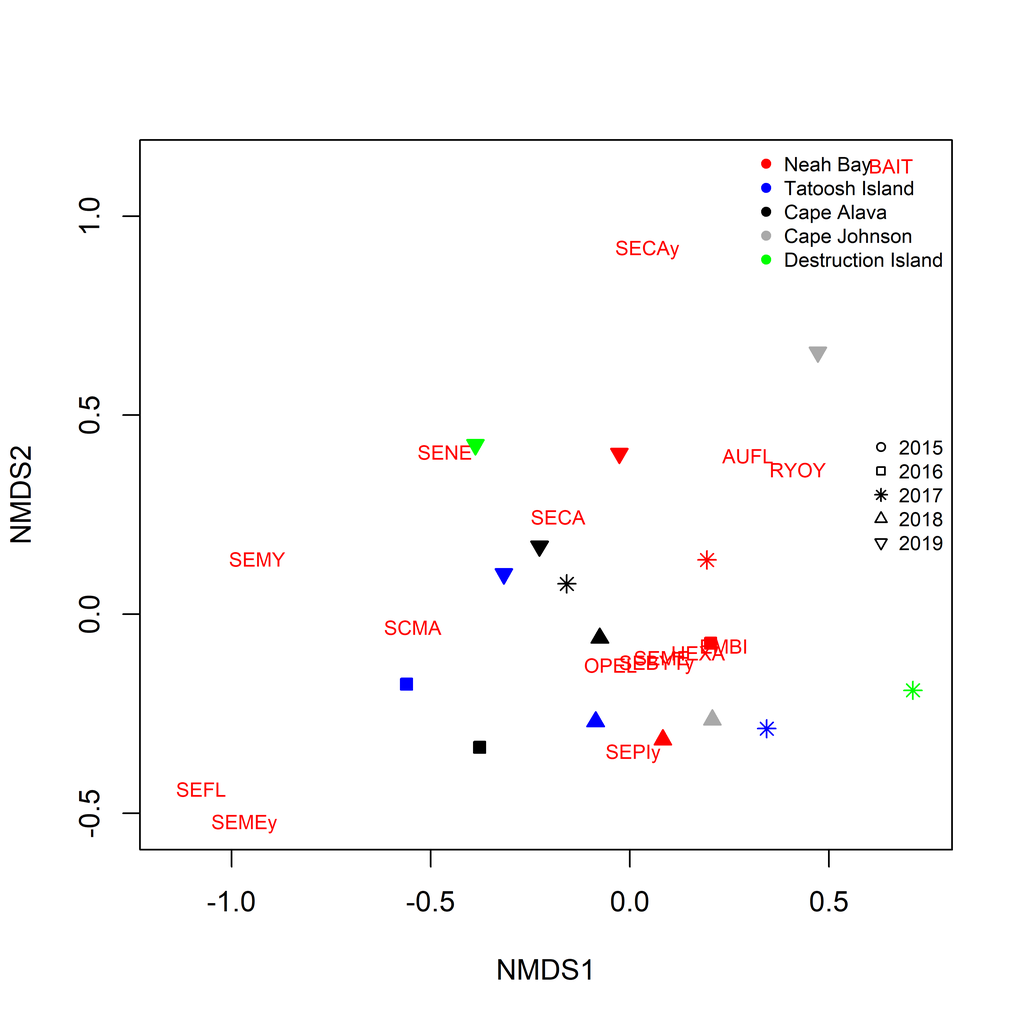

nMDS ordination plot of mean fish abudnace by site x year.

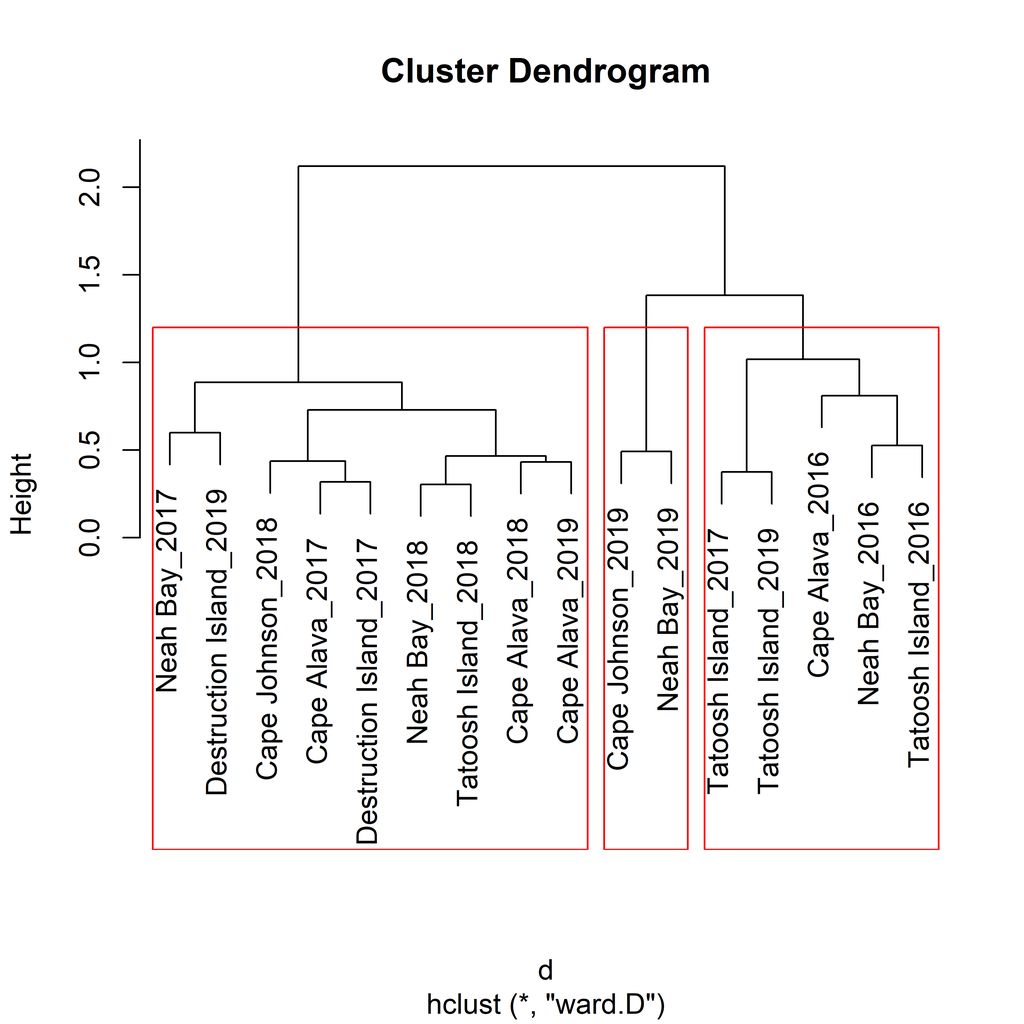

# 3 Constrained Ordinations

DATA TRANSFORM: none

## 3.1 Basic - Discriminat CAP Site x Depth x Year

### 3.1.1 Permanova

```
## Permutation: free
## Number of permutations: 999
##
## Terms added sequentially (first to last)
##
##                 Df SumsOfSqs MeanSqs F.Model      R2 Pr(>F)
## SITE             4     3.004 0.75100  3.4275 0.08921  0.001 ***
## ZONE             1     0.995 0.99455  4.5391 0.02954  0.001 ***
## YEAR             1     2.241 2.24097 10.2277 0.06655  0.001 ***
## SITE:ZONE        4     1.616 0.40388  1.8433 0.04798  0.004 **
## SITE:YEAR        4     2.144 0.53606  2.4465 0.06368  0.001 ***
## ZONE:YEAR        1     0.635 0.63516  2.8988 0.01886  0.005 **
## SITE:ZONE:YEAR   3     1.127 0.37577  1.7150 0.03348  0.015 *
## Residuals      100    21.911 0.21911         0.65070
## Total          118    33.673                 1.00000
## ---
## Signif. codes:  0 '***' 0.001 '**' 0.01 '*' 0.05 '.' 0.1 ' ' 1
```

### 3.1.2 CAP

### 3.1.3 capscale - site x year x depth

- Used this because capscale produces species scores.
- Capscale is more of and rds approach.
- Produces cleaner and nicer plots than CAPdiscrim. I would use this.

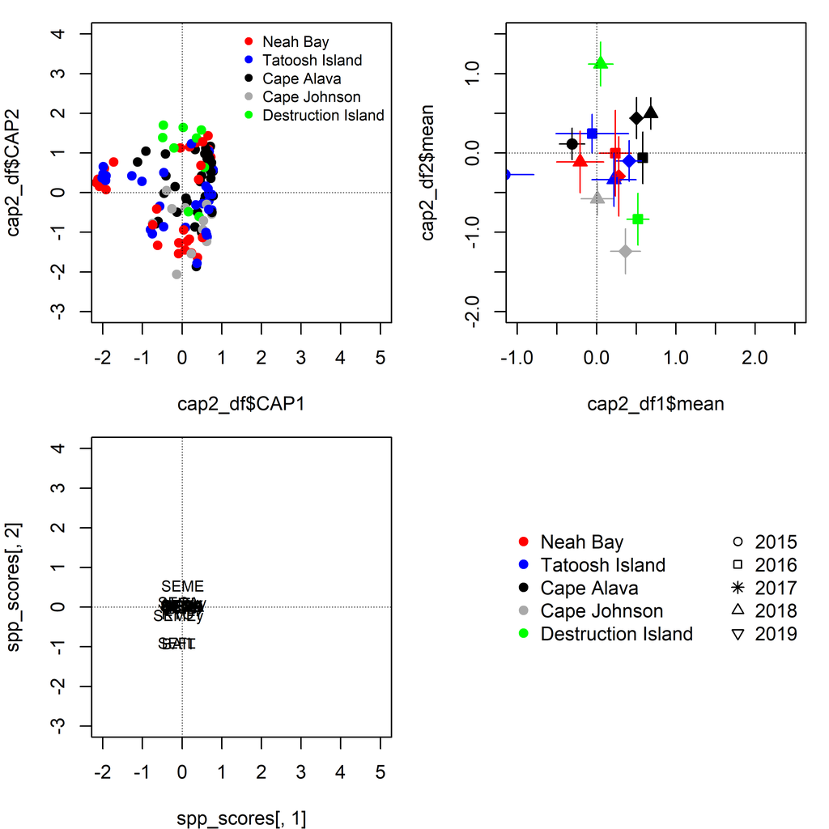

Ordination plot for CAP based on site x year x depth. Error bars are +/- 1.0 s.e.

### 3.1.4 Site x Year

capscale analysis but with year x site as groups

[figure not shown]

Ordination plot for CAP based on site x year x depth. Error bars are +/- 1.0 s.e.

### 3.1.5 capscale - sites only

This analysis uses only sites as the category in the initial rda analyses. The results are more clear and consistent with all the previous ones.

Since we are largely interested in site differences, I think we could use this or the nMDS plots to summarize the fish community.

Note, however, that there was significant multivariate dispersion (p = 0, differences in multivariate variance). So some of the difference has to do with some sites being more variable than others.

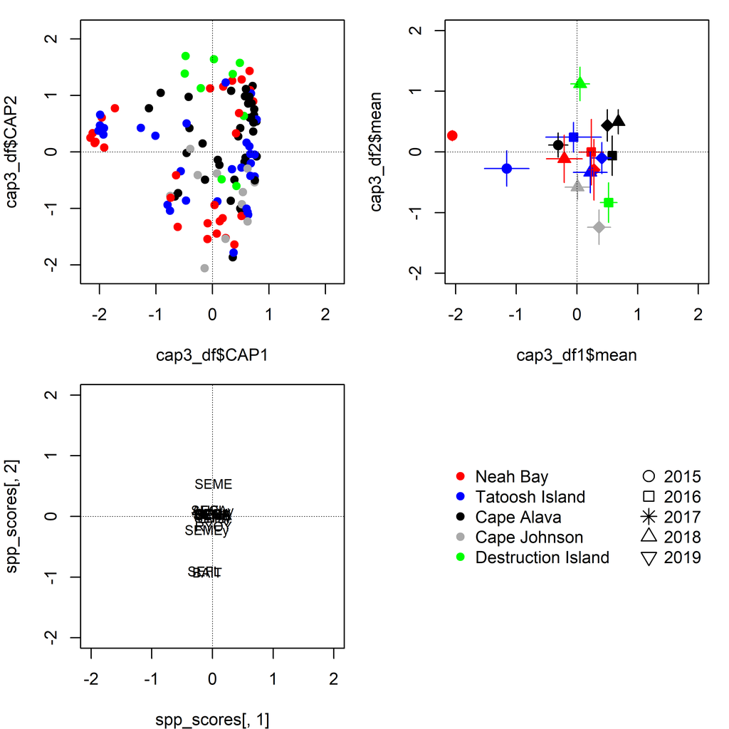

Ordination plot for CAP based on site x year x depth. Error bars are +/- 1.0 s.e.

# 4 Fish - Habitat Associations

## 4.1 CAP fish vs habitat by zone

I think the site x year x zone makes the most sense here:

- Habitat and fish were not on the same transects
- Site x Depth x Year is the smallest scale association of fish vs habitat
- Site x Depth x Year gives us the most data to use for the ordinations
- Site x Depth x Year gets the closes to spp vs habitat associations

There was a significant relationship between fish assembalge structure and abiotic habitat, defined here as the combination of substrate type and relief.

```
## Permutation test for capscale under reduced model
## Permutation: free
## Number of permutations: 999
##
## Model: capscale(formula = fish ~ BEDRK + BOULD + COB + SAND + `>2m` + `0-10cm` + `10cm-1m` + `1m-2m`, data = rock, distance = "bray")
##          Df SumOfSqs      F Pr(>F)
## Model     6   2.4525 1.6241  0.004 **
## Residual 23   5.7886
## ---
## Signif. codes:  0 '***' 0.001 '**' 0.01 '*' 0.05 '.' 0.1 ' ' 1
```

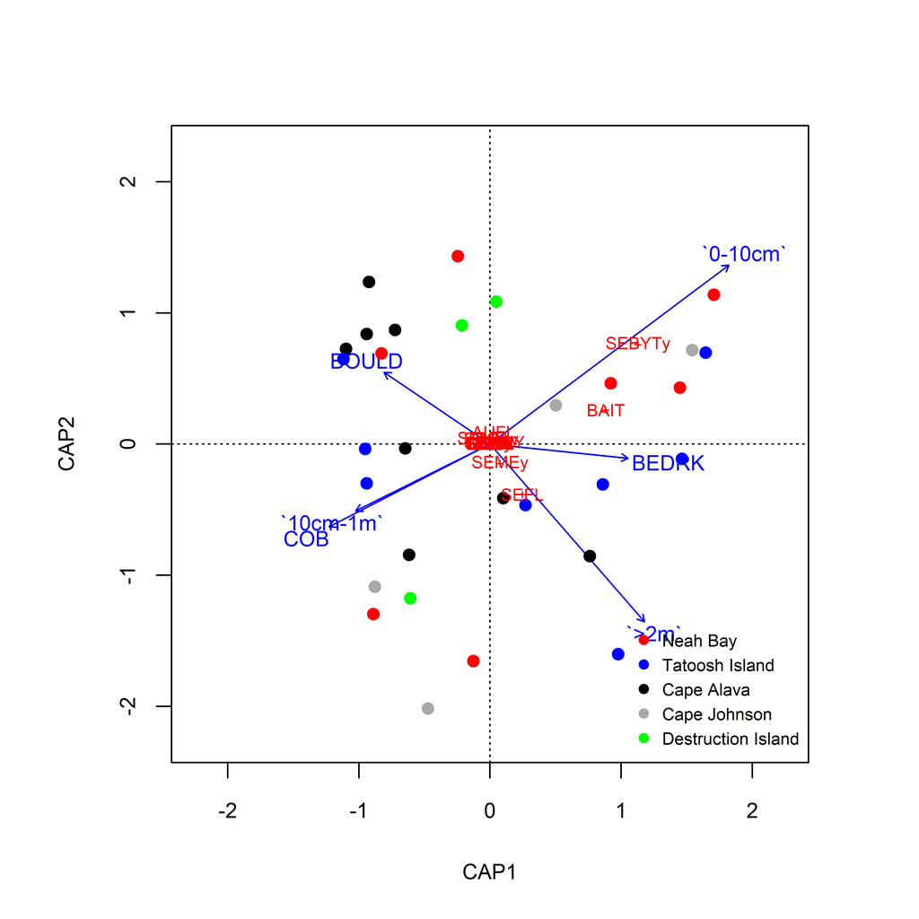

Ordination plot of fish assemblage versus abiotic habitat features.

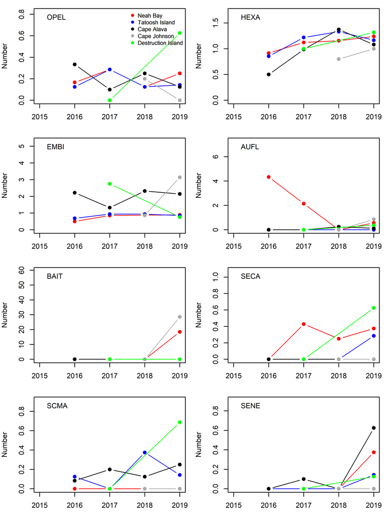

Fish abundance by site and year.

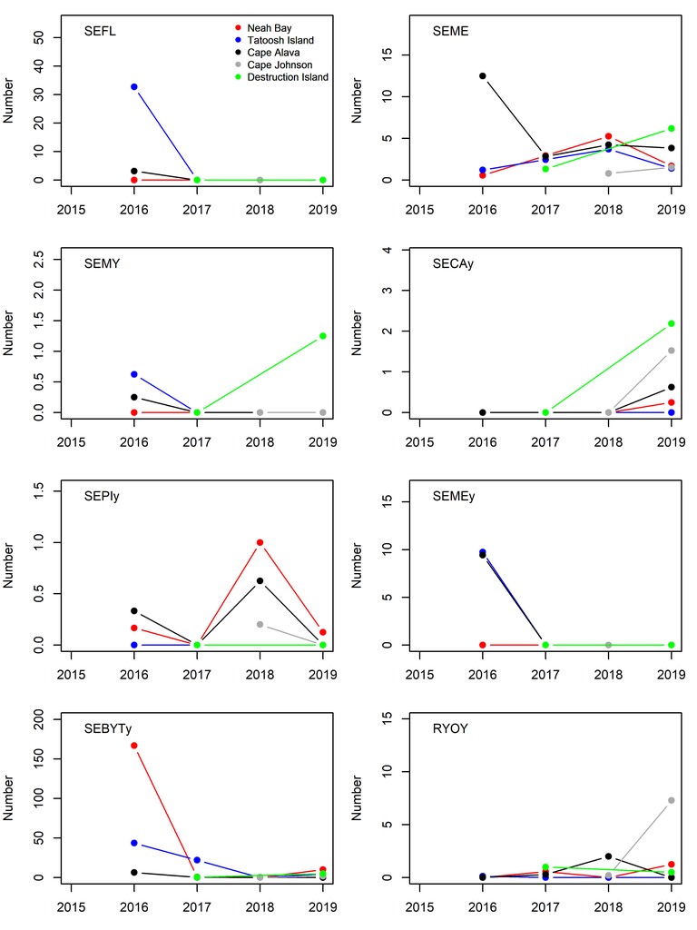

Fish abundance by site and year.